# SVM

bhaskar

Using library *e1071* for SVM svm() - kerner=“linear” - cost = cost of violation to the margin. if cost is large then narrow margnis and few support vectors violating

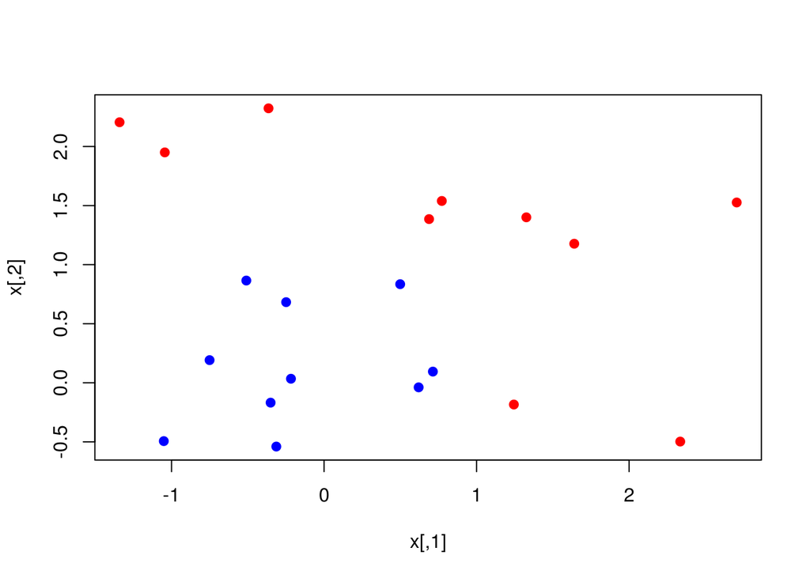

```r
library(e1071)
set.seed(10111)
x = matrix(rnorm(20*2),ncol = 2)
y = rep(c(-1,1),c(10,10))
x[y==1,] = x[y==1,]+1
plot(x,col=3-y,pch = 19)
```

```r
dat = data.frame(x = x, y= as.factor(y))
svmfit = svm(y~.,data = dat,kernel = "linear",cost = 10,scale = F)
```

depending on the application, scaling can be True or false

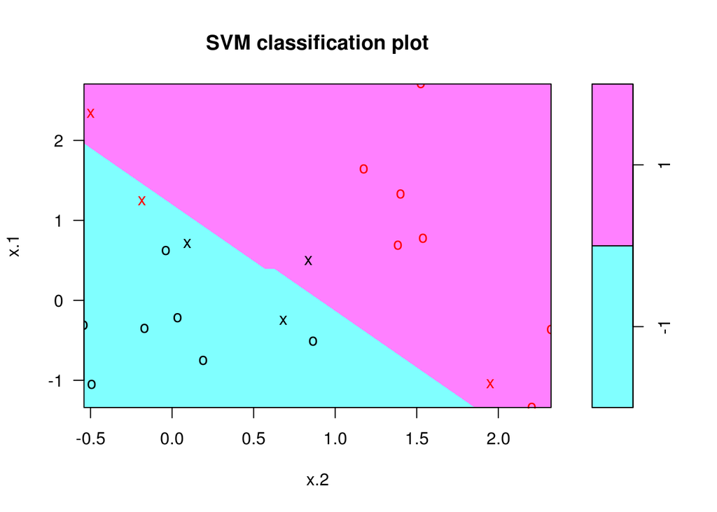

```r
plot(svmfit,data = dat)
```

identities of support vectors can be diplayed by **index** column in the output

```r
svmfit$index
```

```
## [1]  1  4 10 14 16 20
```

```r
summary(svmfit)
```

```
##
## Call:
## svm(formula = y ~ ., data = dat, kernel = "linear", cost = 10,
##     scale = F)
##
##
## Parameters:
##    SVM-Type:  C-classification
##  SVM-Kernel:  linear
##        cost:  10
##       gamma:  0.5
##
## Number of Support Vectors:  6
##
##  ( 3 3 )
##
##
## Number of Classes:  2
##
## Levels:
##  -1 1
```

*cost* is a tuning parameter for the svm(), ususally decided through *crossvalidation* svm for above data using smaller cost

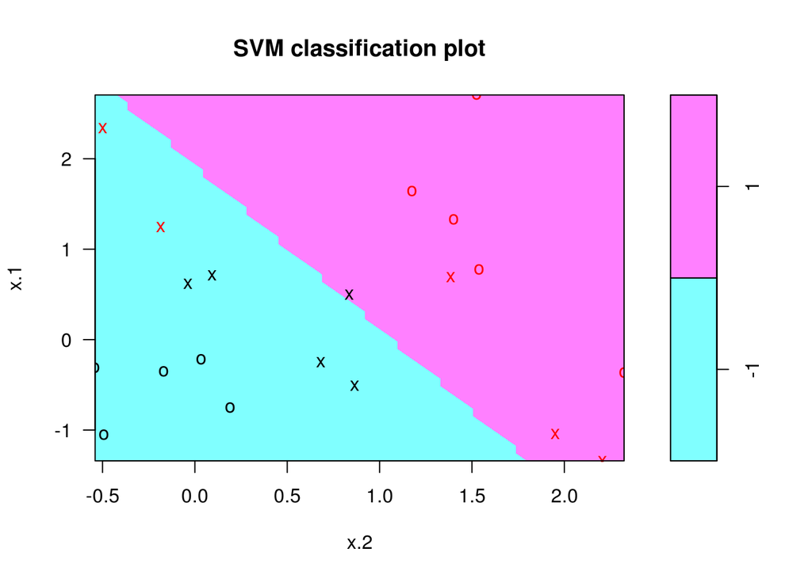

```r
svmfit1 = svm(y~.,data = dat,kernel = "linear",cost = 1,scale = F)
plot(svmfit1,data = dat)
```

```r
svmfit1$index
```

```
##  [1]  1  2  4  8 10 12 14 15 16 20
```

```r
summary(svmfit1)
```

```
##
## Call:
## svm(formula = y ~ ., data = dat, kernel = "linear", cost = 1,
##     scale = F)
##
##
## Parameters:
##    SVM-Type:  C-classification
##  SVM-Kernel:  linear
##        cost:  1
##       gamma:  0.5
##
## Number of Support Vectors:  10
##
##  ( 5 5 )
##
##
## Number of Classes:  2
##
## Levels:
##  -1 1
```

SVM neuther outputs the coefficients of linear boundary or the width of the margin, cross validation is done using the tune() of e1071 library

```r
set.seed(1)
tune.out = tune(svm,y~.,data = dat,kernel="linear",ranges = list(cost=c(0.001,0.01,0.1,1.5,10,100)))
summary(tune.out)
```

```
##
## Parameter tuning of 'svm':
##
## - sampling method: 10-fold cross validation
##
## - best parameters:
##  cost
##   100
##
## - best performance: 0.1
##
## - Detailed performance results:
##      cost error dispersion
## 1   0.001  0.70  0.4216370
## 2   0.010  0.70  0.4216370
## 3   0.100  0.20  0.2581989
## 4   1.500  0.25  0.2635231
## 5  10.000  0.15  0.2415229
## 6 100.000  0.10  0.2108185
```

```r
#best model summary stored in best model column of the output
summary(tune.out$best.model)
```

```
##
## Call:
## best.tune(method = svm, train.x = y ~ ., data = dat, ranges = list(cost = c(0.001,
##     0.01, 0.1, 1.5, 10, 100)), kernel = "linear")
##
##
## Parameters:
##    SVM-Type:  C-classification
##  SVM-Kernel:  linear
##        cost:  100
##       gamma:  0.5
##
## Number of Support Vectors:  5
##
##  ( 2 3 )
##
##
## Number of Classes:  2
##
## Levels:
##  -1 1
```

check performance on a test set

```r
set.seed(10)
xtest = matrix(rnorm(20*2),ncol = 2)
ytest = rep(c(-1,1),c(10,10))
xtest[ytest==1,] = xtest[ytest==1,]+1
test.data = data.frame(x=xtest,y=as.factor(ytest))
yhat.predict = predict(tune.out$best.model,test.data)
table(yhat.predict,test.data$y)
```

```
##
## yhat.predict -1  1
##           -1 10  4
##           1   0  6
```

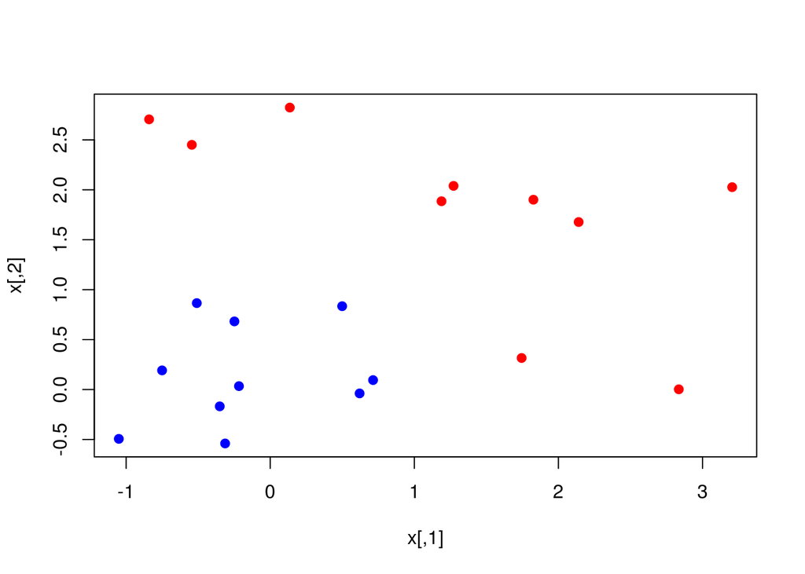

```r
x[y==1,] = x[y==1]+0.5
plot(x,col=3-y,pch=19)
```

```r
dat = data.frame(x = x, y= as.factor(y))
svm.fit2 = svm(y~.,data = dat,cost = 100,scale = F)
table(predict(svm.fit2,test.data),test.data$y)
```

```
##
##      -1 1
##   -1  8 3
##   1   2 7
```

```r
tune.out = tune(svm,y~.,data = dat,kernel="linear",ranges = list(cost=c(0.001,0.01,0.1,1,5,10,100,1000,10000)))
summary(tune.out)
```

```
##
## Parameter tuning of 'svm':
##
## - sampling method: 10-fold cross validation
##
## - best parameters:
##  cost
##     1
##
## - best performance: 0
##
## - Detailed performance results:
##    cost error dispersion
## 1 1e-03  0.40  0.5163978
## 2 1e-02  0.40  0.5163978
## 3 1e-01  0.05  0.1581139
## 4 1e+00  0.00  0.0000000
## 5 5e+00  0.05  0.1581139
## 6 1e+01  0.10  0.2108185
## 7 1e+02  0.10  0.2108185
## 8 1e+03  0.10  0.2108185
## 9 1e+04  0.10  0.2108185
```

```r
yhat.predict = predict(tune.out$best.model,test.data)
table(yhat.predict,test.data$y)
```

```
##
## yhat.predict -1  1
##           -1 10  4
##           1   0  6
```

svm with kernel=“polynomial”/“radial” is non linear

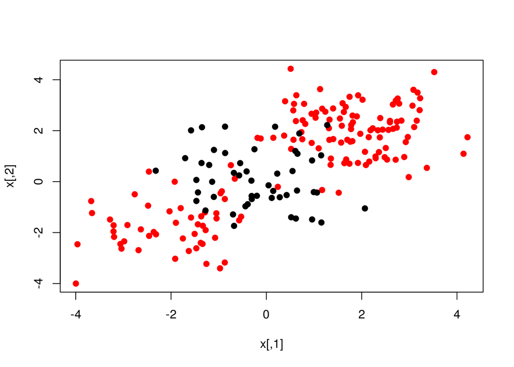

```r
set.seed(10)
x = matrix(rnorm(200*2),ncol = 2)
y = rep(c(1,2),c(150,50))
x[1:100,] = x[1:100,]+2
x[101:150,]=x[101:150,]-2
plot(x,col=3-y,pch=19)
```

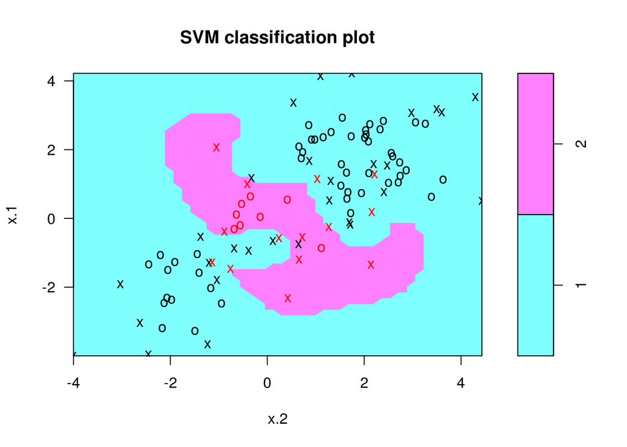

```r
dat = data.frame(x = x,y=as.factor(y))
set.seed(10)
train = sample(200,100)
svm.fit = svm(y~.,kernel="radial",cost = 10,gamma= 1,scale = F,data = dat[train,])
plot(svm.fit,data=dat[train,])
```

```r
table(predict(svm.fit,newdata = dat[-train,]),dat[-train,]$y)
```

```
##
##      1  2
##   1 69  8
##   2  3 20
```

```r
#tune for gamma and cost
tune.out = tune(svm,y~.,data = dat[train,],kernel="radial",ranges = list(cost=c(0.01,0.1,1,10,100,1000),gamma=c(0.5,1,2,3,4)))
summary(tune.out)
```

```
##
## Parameter tuning of 'svm':
##
## - sampling method: 10-fold cross validation
##
## - best parameters:
##  cost gamma
##    10   0.5
##
## - best performance: 0.13
##
## - Detailed performance results:
##     cost gamma error dispersion
## 1  1e-02   0.5  0.22 0.16193277
## 2  1e-01   0.5  0.22 0.16193277
```

[output cut: 28 more lines]

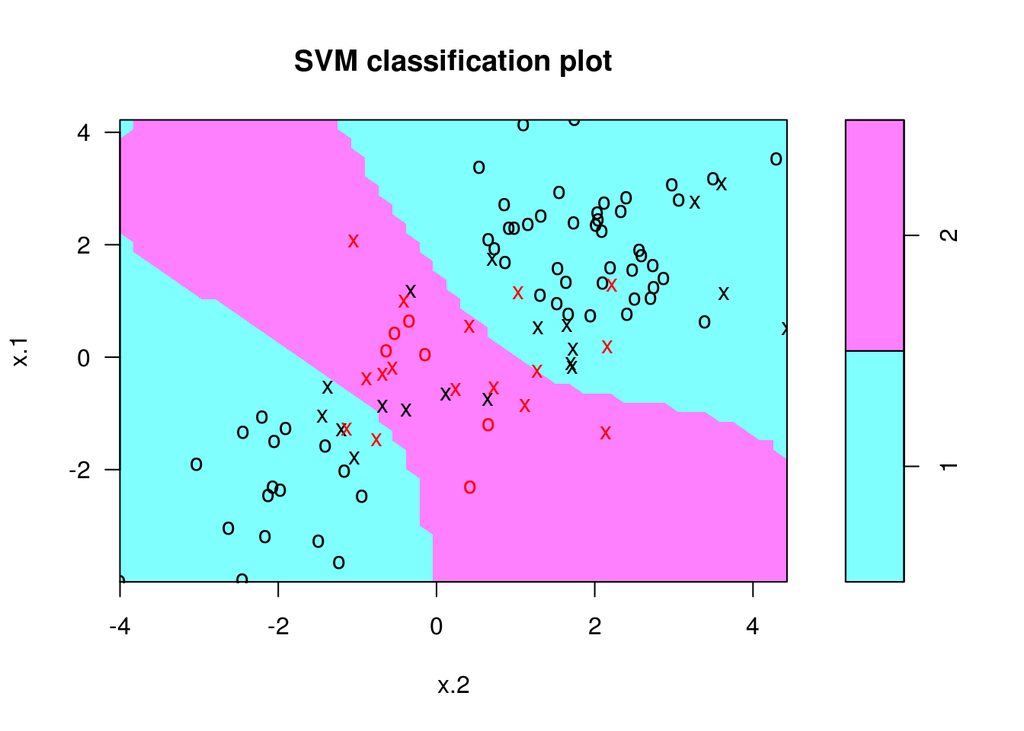

```r
plot(tune.out$best.model,data = dat[train,])
```

```r
table(predict=predict(tune.out$best.model,newdata = dat[-train,]),true=dat[-train,]$y)
```

```
##        true
## predict  1  2
##       1 67  6
##       2  5 22
```

**ROC plots**

```r
library(ROCR)
```

```r
rocplot = function(pred,thruth,...){
        predob = prediction(pred,thruth)
        perf = performance(prediction.obj = predob,measure = "tpr",x.measure = "fpr")
        plot(perf,...)
}
```

By default *svm* function outputs class labels, if we want fitted values instead argument *decision.values=T*

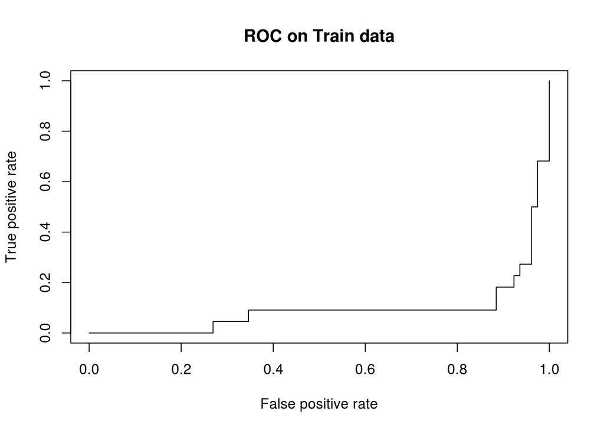

```r
svmfit = svm(y~., data = dat[train,],kernel="radial",gamma=2,cost=1,decision.values=T)
yhat = predict(svmfit,newdata=dat[train,],decision.values= T)
fitted = attributes(yhat)$decision.values
rocplot(fitted,dat[train,"y"],main="ROC on Train data")
```

*svm* produces better flexible fit with higher value of gamma

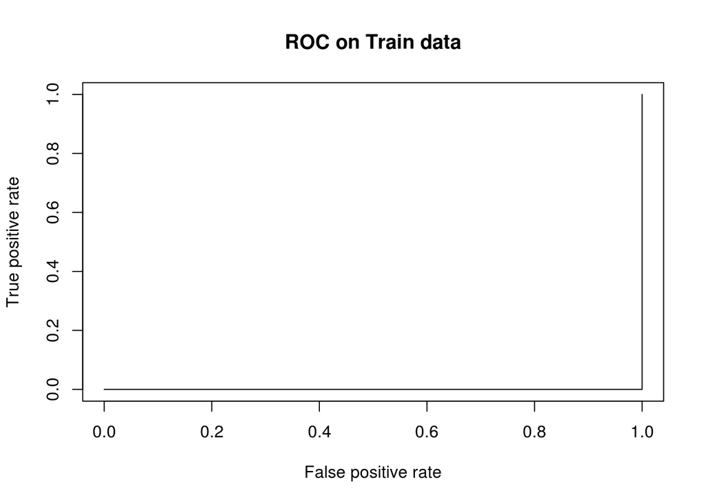

```r
svmfit = svm(y~., data = dat[train,],kernel="radial",gamma=50,cost=1,decision.values=T)
yhat = predict(svmfit,newdata=dat[train,],decision.values= T)
fitted = attributes(yhat)$decision.values
rocplot(fitted,dat[train,"y"],main="ROC on Train data")
```

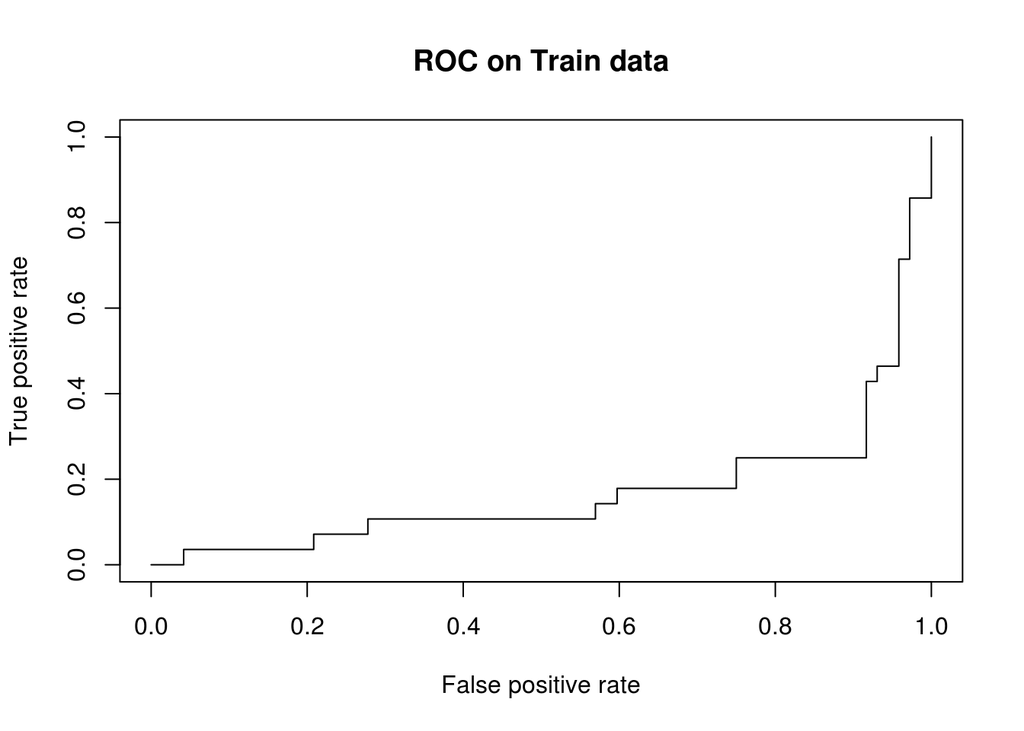

```r
yhat = predict(svmfit,newdata=dat[-train,],decision.values= T)
fitted = attributes(yhat)$decision.values
rocplot(fitted,dat[-train,"y"],main="ROC on Train data")
```

**SVM for multiple classes** performing svm on previous data by adding a third class, *svm* function performs one vs one apprach for the dataset

```r
set.seed(1)
x= rbind(x,matrix(rnorm(50*2),ncol=2))
y = c(y,rep(0,50))
x[y %in% c(0,2)]=x[y %in% c(0,2)]+2
dat = data.frame(x,as.factor(y))
svm.fit2 = svm(y~.,data = dat,kernel="radial",gamma=1,cost=1)
summary(svm.fit)
```

```
##
## Call:
## svm(formula = y ~ ., data = dat[train, ], kernel = "radial",
##     cost = 10, gamma = 1, scale = F)
##
##
## Parameters:
##    SVM-Type:  C-classification
##  SVM-Kernel:  radial
##        cost:  10
##       gamma:  1
##
## Number of Support Vectors:  43
##
##  ( 29 14 )
##
##
## Number of Classes:  2
##
## Levels:
##  1 2
```

```r
plot(svm.fit2,dat)
```

[output not shown]

### Application to gene expression data

For *Khan data set* which consists of gene expression measurement of several tissues of four distinct types of small round blue tumors

```r
library(ISLR)
names(Khan)
```

```
## [1] "xtrain" "xtest"  "ytrain" "ytest"
```

```r
dim(Khan$xtrain)
```

```
## [1]   63 2308
```

```r
dim(Khan$xtest)
```

```
## [1]   20 2308
```

```r
length(Khan$ytrain)
```

```
## [1] 63
```

```r
length(Khan$ytest)
```

```
## [1] 20
```

```r
table(Khan$ytrain)
```

```
##
##  1  2  3  4
##  8 23 12 20
```

```r
table(Khan$ytest)
```

```
##
## 1 2 3 4
## 3 6 6 5
```

```r
dat = data.frame(x=Khan$xtrain,y=as.factor(Khan$ytrain))
svm.model = svm(y~.,data=dat,kernel="linear",cost = 10)
table(svm.model$fitted,dat$y)
```

```
##
##      1  2  3  4
##   1  8  0  0  0
##   2  0 23  0  0
##   3  0  0 12  0
##   4  0  0  0 20
```

```r
dat.te = data.frame(x=Khan$xtest,y=as.factor(Khan$ytest))
table(pred=predict(svm.model,newdata = dat.te),thruth=dat.te$y)
```

```
##     thruth
## pred 1 2 3 4
##    1 3 0 0 0
##    2 0 6 2 0
##    3 0 0 4 0
##    4 0 0 0 5
```

We see that using cost=10 yields in 2 test set errors